# Car Theft Z-Score Analysis

# Analyzing Car Theft Data with Z-Scores

## Introduction

In this notebook, you’ll analyze monthly car theft data from 2017 to 2025 using z-scores. Z-scores help us identify statistically unusual values in our dataset, which can point to important patterns or outliers that deserve journalistic attention.

A z-score tells us how many standard deviations a data point is from the mean. Generally: - Z-scores between -2 and 2 represent typical values (about 95% of the data) - Z-scores beyond ±2 indicate unusual values that might warrant investigation - Z-scores beyond ±3 are very unusual (only about 0.3% of normally distributed data)

## Setup

Let’s start by loading the necessary packages:

```r
library(tidyverse)  # For data manipulation and visualization
library(knitr)      # For nice tables
library(lubridate)  # For working with dates
```

## Loading the Data

We’ll load the car theft data from our CSV file:

```r
# Load car theft data
car_thefts <- read_csv("https://raw.githubusercontent.com/dwillis/jour405/refs/heads/main/data/car_thefts_month17_25.csv")

# Display the first few rows
head(car_thefts)
```

```
## # A tibble: 6 × 3
##   month      total population
##   <date>     <dbl>      <dbl>
## 1 2017-02-01   149     910946
## 2 2017-03-01   195     910946
## 3 2017-04-01   202     910946
## 4 2017-05-01   223     910946
## 5 2017-06-01   278     910946
## 6 2017-07-01   257     910946
```

## Data Exploration

Let’s first understand our dataset structure:

```r
# Get a summary of the data
summary(car_thefts)
```

```
##      month                total         population
##  Min.   :2017-02-01   Min.   :138.0   Min.   :910946
##  1st Qu.:2019-02-01   1st Qu.:193.0   1st Qu.:911562
##  Median :2021-02-01   Median :224.0   Median :956533
##  Mean   :2021-01-30   Mean   :290.1   Mean   :942414
##  3rd Qu.:2023-02-01   3rd Qu.:358.0   3rd Qu.:965398
##  Max.   :2025-02-01   Max.   :685.0   Max.   :966629
```

```r
# Check dimensions
dim(car_thefts)
```

```
## [1] 97  3
```

```r
# Check for missing values
sum(is.na(car_thefts))
```

```
## [1] 0
```

Now let’s create a time series visualization of car thefts:

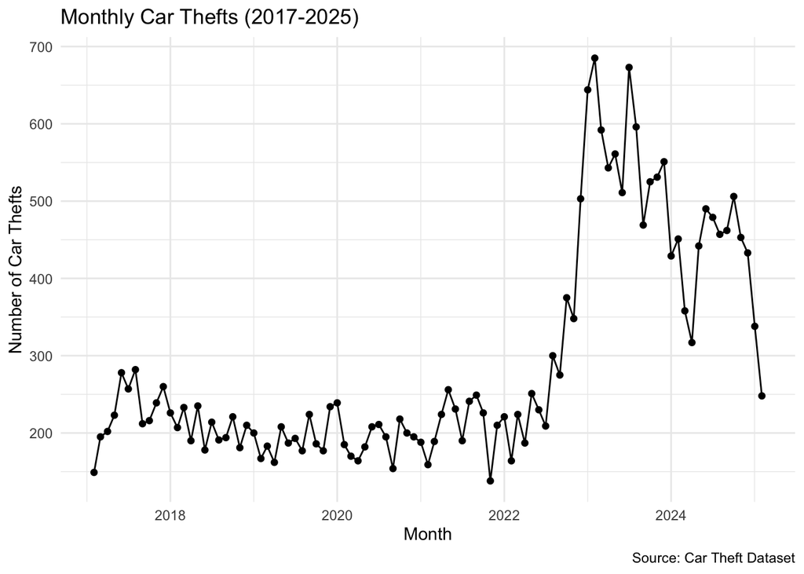

```r
# Convert month to proper date format (assuming format like "Jan 2017")
car_thefts <- car_thefts %>%
  mutate(date = parse_date_time(month, "my"))

# Plot time series
ggplot(car_thefts, aes(x = month, y = total)) +
  geom_line() +
  geom_point() +
  theme_minimal() +
  labs(title = "Monthly Car Thefts (2017-2025)",
       x = "Month",
       y = "Number of Car Thefts",
       caption = "Source: Car Theft Dataset")
```

## Calculating Z-Scores

Now, let’s calculate z-scores for our car theft totals:

```r
# Calculate z-scores for total car thefts
car_thefts <- car_thefts %>%
  mutate(
    mean_thefts = mean(total),
    sd_thefts = sd(total),
    z_score = (total - mean_thefts) / sd_thefts
  )

# Display the data with z-scores
car_thefts %>%
  select(month, total, z_score) %>%
  head(10) %>%
  kable(digits = 2)
```

| month | total | z_score |
| --- | --- | --- |
| 2017-02-01 | 149 | -1.00 |
| 2017-03-01 | 195 | -0.68 |
| 2017-04-01 | 202 | -0.63 |
| 2017-05-01 | 223 | -0.48 |
| 2017-06-01 | 278 | -0.09 |
| 2017-07-01 | 257 | -0.24 |
| 2017-08-01 | 282 | -0.06 |
| 2017-09-01 | 212 | -0.56 |
| 2017-10-01 | 216 | -0.53 |
| 2017-11-01 | 239 | -0.36 |

## Identifying Unusual Months

Let’s identify months with unusually high or low car theft numbers (|z-score| > 2):

```r
# Find months with unusual car theft numbers
unusual_months <- car_thefts %>%
  filter(abs(z_score) > 2) %>%
  arrange(desc(abs(z_score)))

# Display unusual months
unusual_months %>%
  select(month, total, z_score) %>%
  kable(digits = 2)
```

| month | total | z_score |
| --- | --- | --- |
| 2023-02-01 | 685 | 2.81 |
| 2023-07-01 | 673 | 2.72 |
| 2023-01-01 | 644 | 2.51 |
| 2023-08-01 | 596 | 2.17 |
| 2023-03-01 | 592 | 2.15 |

Let’s visualize these unusual months:

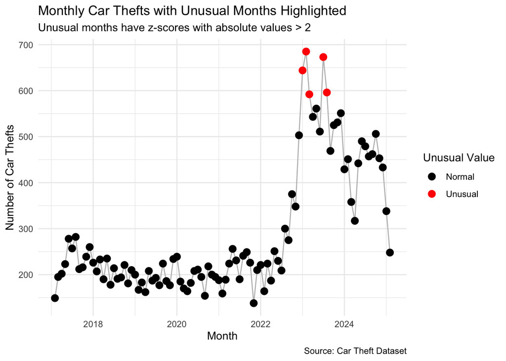

```r
# Highlight unusual months in the time series
ggplot(car_thefts, aes(x = month, y = total, color = abs(z_score) > 2)) +
  geom_line(color = "gray") +
  geom_point(size = 3) +
  scale_color_manual(values = c("black", "red"),
                     name = "Unusual Value",
                     labels = c("Normal", "Unusual")) +
  theme_minimal() +
  labs(title = "Monthly Car Thefts with Unusual Months Highlighted",
       subtitle = "Unusual months have z-scores with absolute values > 2",
       x = "Month",
       y = "Number of Car Thefts",
       caption = "Source: Car Theft Dataset")
```

## Adjusting for Population

Raw numbers might be misleading if the population changes over time. Let’s calculate car thefts per 100,000.

```r
# Calculate thefts per 100,000 population
car_thefts <- car_thefts %>%
  mutate(
    thefts_per_100k = (total / population) * 100000,
    mean_per_100k = mean(thefts_per_100k),
    sd_per_100k = sd(thefts_per_100k),
    z_score_per_100k = (thefts_per_100k - mean_per_100k) / sd_per_100k
  )

# Display the first few rows with per capita rates
car_thefts %>%
  select(month, total, population, thefts_per_100k, z_score_per_100k) %>%
  head(10) %>%
  kable(digits = 2)
```

| month | total | population | thefts_per_100k | z_score_per_100k |
| --- | --- | --- | --- | --- |
| 2017-02-01 | 149 | 910946 | 16.36 | -0.99 |
| 2017-03-01 | 195 | 910946 | 21.41 | -0.64 |
| 2017-04-01 | 202 | 910946 | 22.17 | -0.59 |
| 2017-05-01 | 223 | 910946 | 24.48 | -0.43 |
| 2017-06-01 | 278 | 910946 | 30.52 | -0.01 |
| 2017-07-01 | 257 | 910946 | 28.21 | -0.17 |
| 2017-08-01 | 282 | 910946 | 30.96 | 0.02 |
| 2017-09-01 | 212 | 910946 | 23.27 | -0.51 |
| 2017-10-01 | 216 | 910946 | 23.71 | -0.48 |
| 2017-11-01 | 239 | 910946 | 26.24 | -0.31 |

Let’s find months with unusual per capita theft rates:

```r
# Find months with unusual per capita theft rates
unusual_per_capita <- car_thefts %>%
  filter(abs(z_score_per_100k) > 2) %>%
  arrange(desc(abs(z_score_per_100k)))

# Display unusual per capita months
unusual_per_capita %>%
  select(month, thefts_per_100k, z_score_per_100k) %>%
  kable(digits = 2)
```

| month | thefts_per_100k | z_score_per_100k |
| --- | --- | --- |
| 2023-02-01 | 71.61 | 2.83 |
| 2023-07-01 | 70.36 | 2.75 |
| 2023-01-01 | 67.33 | 2.54 |
| 2023-08-01 | 62.31 | 2.19 |
| 2023-03-01 | 61.89 | 2.16 |

Visualize the per capita rates:

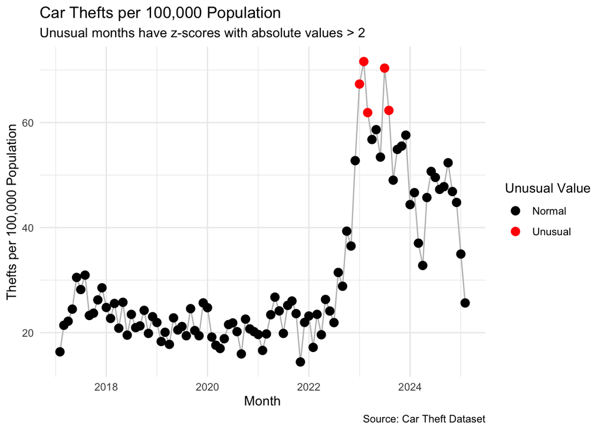

```r
# Plot per capita theft rates
ggplot(car_thefts, aes(x = month, y = thefts_per_100k, color = abs(z_score_per_100k) > 2)) +
  geom_line(color = "gray") +
  geom_point(size = 3) +
  scale_color_manual(values = c("black", "red"),
                     name = "Unusual Value",
                     labels = c("Normal", "Unusual")) +
  theme_minimal() +
  labs(title = "Car Thefts per 100,000 Population",
       subtitle = "Unusual months have z-scores with absolute values > 2",
       x = "Month",
       y = "Thefts per 100,000 Population",
       caption = "Source: Car Theft Dataset")
```

## Comparing Raw Numbers vs. Per Capita Rates

It’s interesting to compare which months stand out as unusual based on raw numbers versus per capita rates:

```r
# Combine unusual months from both metrics
unusual_combined <- car_thefts %>%
  filter(abs(z_score) > 2 | abs(z_score_per_100k) > 2) %>%
  select(month, total, z_score, thefts_per_100k, z_score_per_100k) %>%
  arrange(month)

# Display combined unusual months
unusual_combined %>%
  kable(digits = 2)
```

| month | total | z_score | thefts_per_100k | z_score_per_100k |
| --- | --- | --- | --- | --- |
| 2023-01-01 | 644 | 2.51 | 67.33 | 2.54 |
| 2023-02-01 | 685 | 2.81 | 71.61 | 2.83 |
| 2023-03-01 | 592 | 2.15 | 61.89 | 2.16 |
| 2023-07-01 | 673 | 2.72 | 70.36 | 2.75 |
| 2023-08-01 | 596 | 2.17 | 62.31 | 2.19 |

## Seasonal Patterns

Let’s also check if there are seasonal patterns in car thefts:

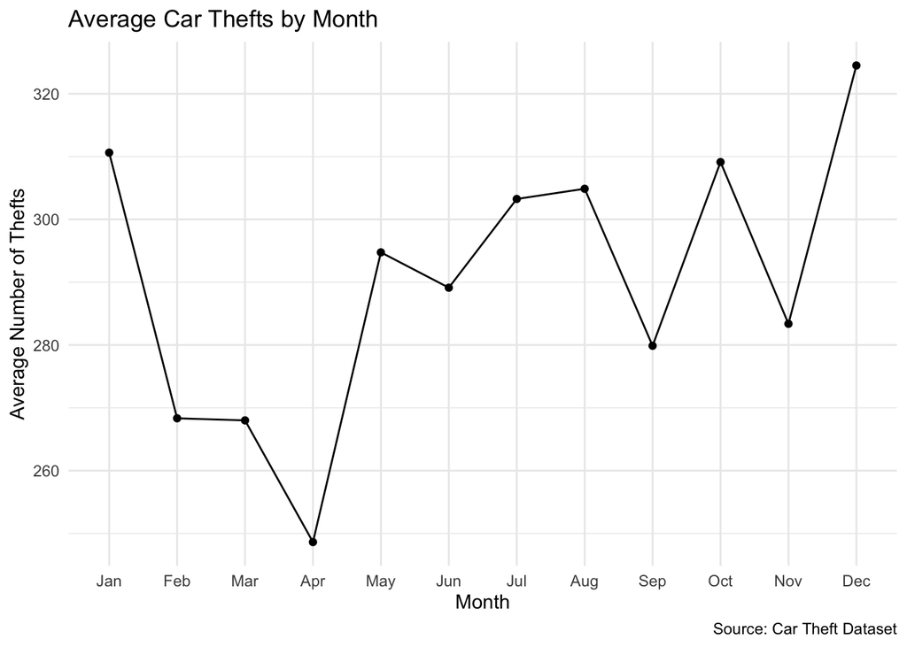

```r
# Extract month from date
car_thefts <- car_thefts %>%
  mutate(month_of_year = month(month, label = TRUE))

# Calculate average thefts by month
monthly_pattern <- car_thefts %>%
  group_by(month_of_year) %>%
  summarize(
    avg_thefts = mean(total),
    avg_per_100k = mean(thefts_per_100k)
  )

# Plot seasonal pattern
ggplot(monthly_pattern, aes(x = month_of_year, y = avg_thefts, group = 1)) +
  geom_line() +
  geom_point() +
  theme_minimal() +
  labs(title = "Average Car Thefts by Month",
       x = "Month",
       y = "Average Number of Thefts",
       caption = "Source: Car Theft Dataset")
```

## Adjusting for Seasonality

We can also calculate z-scores that account for seasonal patterns:

```r
# Calculate seasonal z-scores
car_thefts <- car_thefts %>%
  group_by(month_of_year) %>%
  mutate(
    seasonal_mean = mean(total),
    seasonal_sd = sd(total),
    seasonal_z_score = (total - seasonal_mean) / seasonal_sd
  ) %>%
  ungroup()

# Find months with unusual seasonal z-scores
unusual_seasonal <- car_thefts %>%
  filter(abs(seasonal_z_score) > 2) %>%
  arrange(desc(abs(seasonal_z_score)))

# Display months that are unusual for their season
unusual_seasonal %>%
  select(month, total, seasonal_mean, seasonal_z_score) %>%
  kable(digits = 2)
```

| month | total | seasonal_mean | seasonal_z_score |
| --- | --- | --- | --- |
| 2023-02-01 | 685 | 268.33 | 2.29 |
| 2023-04-01 | 543 | 248.62 | 2.29 |
| 2023-03-01 | 592 | 268.00 | 2.25 |
| 2023-01-01 | 644 | 310.62 | 2.12 |
| 2023-07-01 | 673 | 303.25 | 2.09 |

## Conclusion

Z-scores provide a powerful statistical tool for identifying unusual patterns in time series data like monthly car thefts. By calculating these scores, we can quickly identify months that deviate significantly from the norm, which can lead to journalistic insights and story ideas.

When reporting on these findings, remember to:

1. **Provide Context**: Explain what a z-score means in terms readers can understand
2. **Investigate Causes**: Follow up on unusual values to understand the underlying reasons
3. **Consider Multiple Metrics**: Look at both raw numbers and population-adjusted figures
4. **Account for Seasonality**: Consider whether values are unusual compared to the same time of year